# HOMEWORK_8

Matteo Vantaggio

2024-10-5

## Introduction

The analysis presented in this report is based on the **Oribatid mite** data, which includes information about 35 species of Oribatid mites (Acari: Oribatida) collected from 70 sampling sites in the **Station de biologie des Laurentides** of the University of Montreal, Quebec, Canada, in June 1989. This data set provides a comprehensive view of mite communities in relation to environmental and geographic factors.

```r
data('mite')
data("mite.env")
data('mite.xy')
head(mite)
```

```
##   Brachy PHTH HPAV RARD SSTR Protopl MEGR MPRO TVIE HMIN HMIN2 NPRA TVEL ONOV
## 1     17    5    5    3    2       1    4    2    2    1     4    1   17    4
## 2      2    7   16    0    6       0    4    2    0    0     1    3   21   27
## 3      4    3    1    1    2       0    3    0    0    0     6    3   20   17
## 4     23    7   10    2    2       0    4    0    1    2    10    0   18   47
## 5      5    8   13    9    0      13    0    0    0    3    14    3   32   43
## 6     19    7    5    9    3       2    3    0    0   20    16    2   13   38
##   SUCT LCIL Oribatl1 Ceratoz1 PWIL Galumna1 Stgncrs2 HRUF Trhypch1 PPEL NCOR
## 1    9   50        3        1    1        8        0    0        0    0    0
## 2   12  138        6        0    1        3        9    1        1    1    2
## 3   10   89        3        0    2        1        8    0        3    0    2
## 4   17  108       10        1    0        1        2    1        2    1    3
## 5   27    5        1        0    5        2        1    0        1    0    0
## 6   39    3        5        0    1        1        8    0        4    0    1
##   SLAT FSET Lepidzts Eupelops Miniglmn LRUG PLAG2 Ceratoz3 Oppiminu Trimalc2
## 1    0    0        0        0        0    0     0        0        0        0
## 2    2    2        1        0        0    0     0        0        0        0
## 3    0    8        0        0        0    0     0        0        0        0
## 4    2   12        0        0        0    0     0        0        0        0
## 5    0   12        2        0        0    0     0        0        0        0
## 6    0   10        0        0        0    0     0        0        0        0
```

```r
head(mite.env)
```

```
##   SubsDens WatrCont Substrate Shrub    Topo
## 1    39.18   350.15   Sphagn1   Few Hummock
## 2    54.99   434.81    Litter   Few Hummock
## 3    46.07   371.72 Interface   Few Hummock
## 4    48.19   360.50   Sphagn1   Few Hummock
## 5    23.55   204.13   Sphagn1   Few Hummock
## 6    57.32   311.55   Sphagn1   Few Hummock
```

```r
head(mite.xy)
```

```
##     x   y
## 1 0.2 0.1
## 2 1.0 0.1
## 3 1.2 0.3
## 4 1.4 0.5
## 5 2.4 0.7
## 6 1.8 0.9
```

- **mite**: This dataset contains the abundances of 35 morphospecies of Oribatid mites across 70 cores of mostly Sphagnum mosses. The data was collected from a variety of locations, providing insights into species diversity and distribution within the study area.
- **mite.env**: This dataset contains 5 environmental covariates (e.g., substrate and microtopographic variables) for each of the 70 sampling sites, offering contextual information to assess how environmental factors influence mite communities.
- **mite.xy**: This dataset provides the geographic coordinates (x, y) of the 70 sampling sites, enabling spatial analysis of mite distribution and environmental gradients.

Oribatid mites are a highly diverse group of small, soil-dwelling arthropods, typically ranging in size from 0.2 to 1.2 mm. These mites are predominantly microphytophagous and detritivorous, thriving in well-aerated soils or complex substrates like Sphagnum mosses found in bogs and wet forests. In these environments, the abundance of mites can reach several hundred thousand individuals per square meter. Local assemblages can include over a hundred species, many of which are rare, making them an interesting subject for studying community-environment relationships at fine spatial scales.

This dataset, organized by the abundance of each mite species at the sampling sites, provides valuable insights into how environmental factors may shape the distribution and diversity of Oribatid mites within the studied area.

## Exploratory Data Analysis

We begin by summarizing the datasets to understand their structure and contents.

```r
skim(mite)
```

Data summary

| Name | mite |
| --- | --- |
| Number of rows | 70 |
| Number of columns | 35 |
| _______________________ |  |
| Column type frequency: |  |
| numeric | 35 |
| ________________________ |  |
| Group variables | None |

**Variable type: numeric**

| skim_variable | n_missing | complete_rate | mean | sd | p0 | p25 | p50 | p75 | p100 | hist |
| --- | --- | --- | --- | --- | --- | --- | --- | --- | --- | --- |
| Brachy | 0 | 1 | 8.73 | 10.08 | 0 | 3.00 | 4.5 | 11.75 | 42 | ▇▁▂▁▁ |
| PHTH | 0 | 1 | 1.27 | 2.17 | 0 | 0.00 | 0.0 | 2.00 | 8 | ▇▂▁▁▁ |
| HPAV | 0 | 1 | 8.51 | 7.56 | 0 | 4.00 | 6.5 | 12.00 | 37 | ▇▅▂▁▁ |
| RARD | 0 | 1 | 1.21 | 2.78 | 0 | 0.00 | 0.0 | 1.00 | 13 | ▇▁▁▁▁ |
| SSTR | 0 | 1 | 0.31 | 0.97 | 0 | 0.00 | 0.0 | 0.00 | 6 | ▇▁▁▁▁ |
| Protopl | 0 | 1 | 0.37 | 1.61 | 0 | 0.00 | 0.0 | 0.00 | 13 | ▇▁▁▁▁ |
| MEGR | 0 | 1 | 2.19 | 3.62 | 0 | 0.00 | 1.0 | 3.00 | 17 | ▇▁▁▁▁ |
| MPRO | 0 | 1 | 0.16 | 0.47 | 0 | 0.00 | 0.0 | 0.00 | 2 | ▇▁▁▁▁ |
| TVIE | 0 | 1 | 0.83 | 1.47 | 0 | 0.00 | 0.0 | 1.00 | 7 | ▇▁▁▁▁ |
| HMIN | 0 | 1 | 4.91 | 8.47 | 0 | 0.00 | 0.0 | 4.75 | 36 | ▇▁▁▁▁ |
| HMIN2 | 0 | 1 | 1.96 | 3.92 | 0 | 0.00 | 0.0 | 2.75 | 20 | ▇▁▁▁▁ |
| NPRA | 0 | 1 | 1.89 | 2.37 | 0 | 0.00 | 1.0 | 2.75 | 10 | ▇▂▁▁▁ |
| TVEL | 0 | 1 | 9.06 | 10.93 | 0 | 0.00 | 3.0 | 19.00 | 42 | ▇▂▃▁▁ |
| ONOV | 0 | 1 | 17.27 | 18.05 | 0 | 5.00 | 10.5 | 24.25 | 73 | ▇▂▁▁▁ |
| SUCT | 0 | 1 | 16.96 | 13.89 | 0 | 7.25 | 13.5 | 24.00 | 63 | ▇▅▂▁▁ |
| LCIL | 0 | 1 | 35.26 | 88.85 | 0 | 1.25 | 13.0 | 44.00 | 723 | ▇▁▁▁▁ |
| Oribatl1 | 0 | 1 | 1.89 | 3.43 | 0 | 0.00 | 0.0 | 2.75 | 17 | ▇▁▁▁▁ |
| Ceratoz1 | 0 | 1 | 1.29 | 1.46 | 0 | 0.00 | 1.0 | 2.00 | 5 | ▇▂▁▁▁ |
| PWIL | 0 | 1 | 1.09 | 1.71 | 0 | 0.00 | 0.0 | 1.00 | 8 | ▇▂▁▁▁ |
| Galumna1 | 0 | 1 | 0.96 | 1.73 | 0 | 0.00 | 0.0 | 1.00 | 8 | ▇▁▁▁▁ |
| Stgncrs2 | 0 | 1 | 0.73 | 1.83 | 0 | 0.00 | 0.0 | 0.00 | 9 | ▇▁▁▁▁ |
| HRUF | 0 | 1 | 0.23 | 0.62 | 0 | 0.00 | 0.0 | 0.00 | 3 | ▇▁▁▁▁ |
| Trhypch1 | 0 | 1 | 2.61 | 6.14 | 0 | 0.00 | 0.0 | 2.00 | 29 | ▇▁▁▁▁ |
| PPEL | 0 | 1 | 0.17 | 0.54 | 0 | 0.00 | 0.0 | 0.00 | 3 | ▇▁▁▁▁ |
| NCOR | 0 | 1 | 1.13 | 1.65 | 0 | 0.00 | 0.5 | 1.75 | 7 | ▇▁▁▁▁ |
| SLAT | 0 | 1 | 0.40 | 1.23 | 0 | 0.00 | 0.0 | 0.00 | 8 | ▇▁▁▁▁ |
| FSET | 0 | 1 | 1.86 | 3.18 | 0 | 0.00 | 0.0 | 2.00 | 12 | ▇▁▁▁▁ |
| Lepidzts | 0 | 1 | 0.17 | 0.54 | 0 | 0.00 | 0.0 | 0.00 | 3 | ▇▁▁▁▁ |
| Eupelops | 0 | 1 | 0.64 | 0.99 | 0 | 0.00 | 0.0 | 1.00 | 4 | ▇▃▁▁▁ |
| Miniglmn | 0 | 1 | 0.24 | 0.79 | 0 | 0.00 | 0.0 | 0.00 | 5 | ▇▁▁▁▁ |
| LRUG | 0 | 1 | 10.43 | 12.66 | 0 | 0.00 | 4.5 | 17.75 | 57 | ▇▃▂▁▁ |
| PLAG2 | 0 | 1 | 0.80 | 1.79 | 0 | 0.00 | 0.0 | 1.00 | 9 | ▇▁▁▁▁ |
| Ceratoz3 | 0 | 1 | 1.30 | 2.20 | 0 | 0.00 | 0.0 | 2.00 | 9 | ▇▂▁▁▁ |
| Oppiminu | 0 | 1 | 1.11 | 1.84 | 0 | 0.00 | 0.0 | 1.75 | 9 | ▇▂▁▁▁ |
| Trimalc2 | 0 | 1 | 2.07 | 5.79 | 0 | 0.00 | 0.0 | 0.00 | 33 | ▇▁▁▁▁ |

```r
skim(mite.xy)
```

Data summary

| Name | mite.xy |
| --- | --- |
| Number of rows | 70 |
| Number of columns | 2 |
| _______________________ |  |
| Column type frequency: |  |
| numeric | 2 |
| ________________________ |  |
| Group variables | None |

**Variable type: numeric**

| skim_variable | n_missing | complete_rate | mean | sd | p0 | p25 | p50 | p75 | p100 | hist |
| --- | --- | --- | --- | --- | --- | --- | --- | --- | --- | --- |
| x | 0 | 1 | 1.23 | 0.78 | 0.05 | 0.4 | 1.4 | 1.8 | 2.4 | ▇▂▆▅▇ |
| y | 0 | 1 | 5.03 | 2.72 | 0.10 | 2.7 | 5.4 | 7.3 | 9.7 | ▅▇▅▇▇ |

To run autologistic models, we need the data in a presence/absence format. The original data contains abundance counts, so we will convert these into binary presence (1) or absence (0) values for the two species of interest: ONOV and LCIL.

```r
mite_pa <- mite %>%
  mutate(across(c(ONOV, LCIL), ~ ifelse(. > 0, 1, 0)))

# Display summary of the transformed data
summary(mite_pa[,14])
```

```
##    Min. 1st Qu.  Median    Mean 3rd Qu.    Max.
##     0.0     1.0     1.0     0.9     1.0     1.0
```

```r
summary(mite_pa[,16])
```

```
##    Min. 1st Qu.  Median    Mean 3rd Qu.    Max.
##  0.0000  1.0000  1.0000  0.7857  1.0000  1.0000
```

Next, we explore the spatial distribution of the two species, ONOV and LCIL, using their geographic coordinates. We plot the presence and absence of each species at the sampling sites.

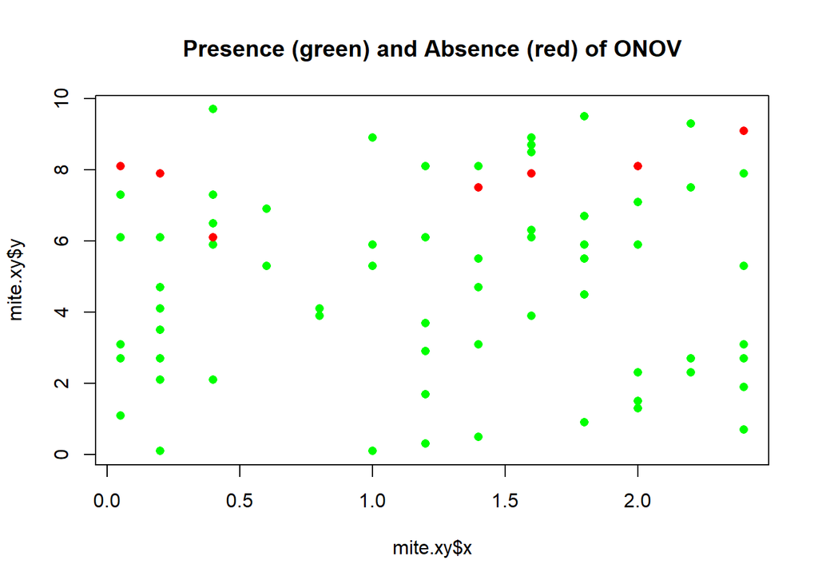

```r
# Plot presence (green) and absence (red) of ONOV
plot(mite.xy$x, mite.xy$y, col = ifelse(mite_pa$ONOV >= 1, "green", "red"), pch = 16,
     main = "Presence (green) and Absence (red) of ONOV")
```

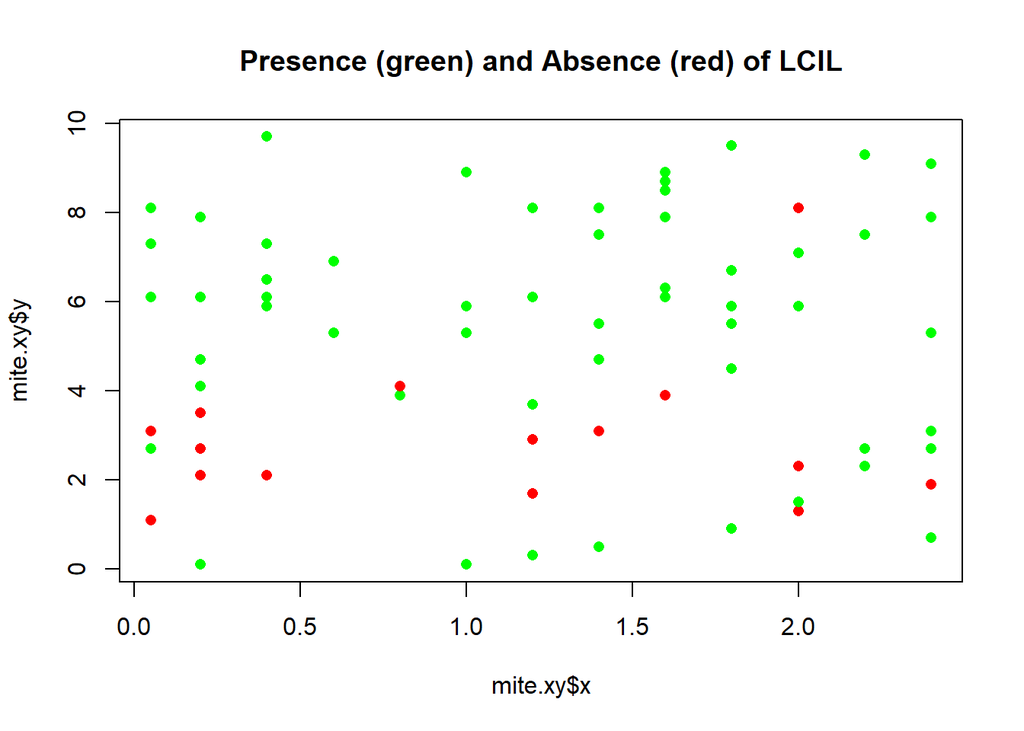

```r
# Plot presence (green) and absence (red) of LCIL
plot(mite.xy$x, mite.xy$y, col = ifelse(mite_pa$LCIL >= 1, "green", "red"), pch = 16,
     main = "Presence (green) and Absence (red) of LCIL")
```

To get a better understanding of the distribution of the levels within the categorical variables, we can use the inspect_cat() function, which provides a visual summary of the factor variables’ levels

```r
mite_env1 <- mite.env %>%
  inspect_cat()
mite_env1$levels$eye_color
```

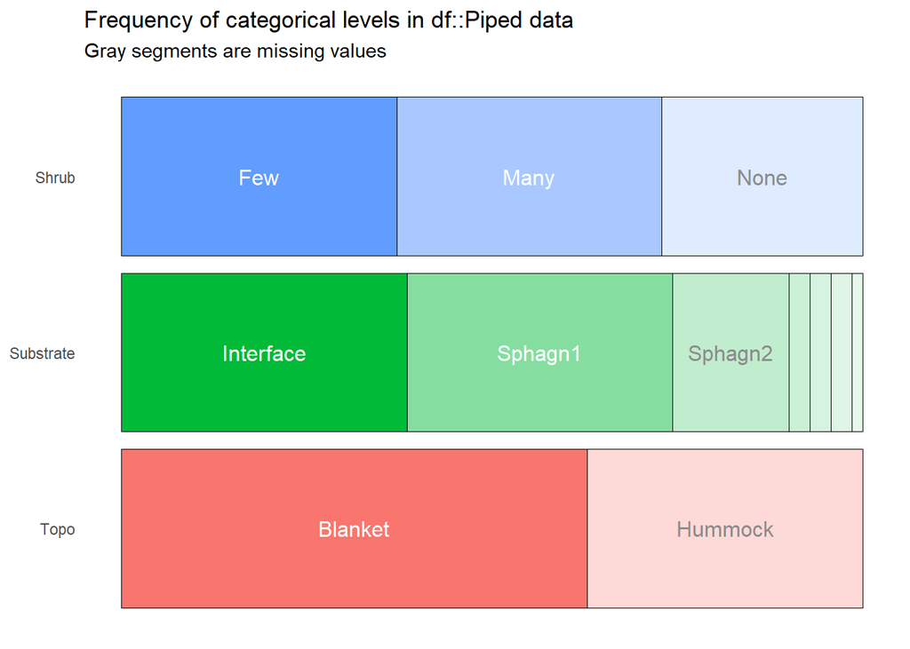

```r
mite_env1 %>%
  show_plot()
```

Next, we combine the presence/absence data (mite_pa), environmental data (mite.env), and geographic coordinates (mite.xy) into one dataset (mite_combined). We then provide numeric summaries of the relationships between the categorical covariates and the presence/absence of ONOV.

```r
# Combine data
mite_combined <- cbind(mite_pa, mite.env, mite.xy)

# Numeric summary for Substrate and ONOV
mite_combined %>%
  group_by(Substrate, ONOV) %>%
  summarise(count = n()) %>%
  spread(key = ONOV, value = count, fill = 0)
```

```
## # A tibble: 7 × 3
## # Groups:   Substrate [7]
##   Substrate   `0`   `1`
##   <fct>     <dbl> <dbl>
## 1 Sphagn1       2    23
## 2 Sphagn2       1    10
## 3 Sphagn3       0     1
## 4 Sphagn4       0     2
## 5 Litter        0     2
## 6 Barepeat      2     0
## 7 Interface     2    25
```

```r
# Numeric summary for Shrub and ONOV
mite_combined %>%
  group_by(Shrub, ONOV) %>%
  summarise(count = n()) %>%
  spread(key = ONOV, value = count, fill = 0)
```

```
## # A tibble: 3 × 3
## # Groups:   Shrub [3]
##   Shrub   `0`   `1`
##   <ord> <dbl> <dbl>
## 1 None      6    13
## 2 Few       1    25
## 3 Many      0    25
```

```r
# Numeric summary for Topo and ONOV
mite_combined %>%
  group_by(Topo, ONOV) %>%
  summarise(count = n()) %>%
  spread(key = ONOV, value = count, fill = 0)
```

```
## # A tibble: 2 × 3
## # Groups:   Topo [2]
##   Topo      `0`   `1`
##   <fct>   <dbl> <dbl>
## 1 Blanket     7    37
## 2 Hummock     0    26
```

We now focus on the two numeric covariates: **SubsDens** (substrate density) and **WatrCont** (water content of the substrate). We will visualize their distributions in relation to the presence or absence of **ONOV** using boxplots. The following boxplot visualizes the distribution of **SubsDens** (substrate density) for the two levels of **ONOV** (presence/absence). The plot helps us assess how the substrate density varies between sites where **ONOV** is present versus absent.

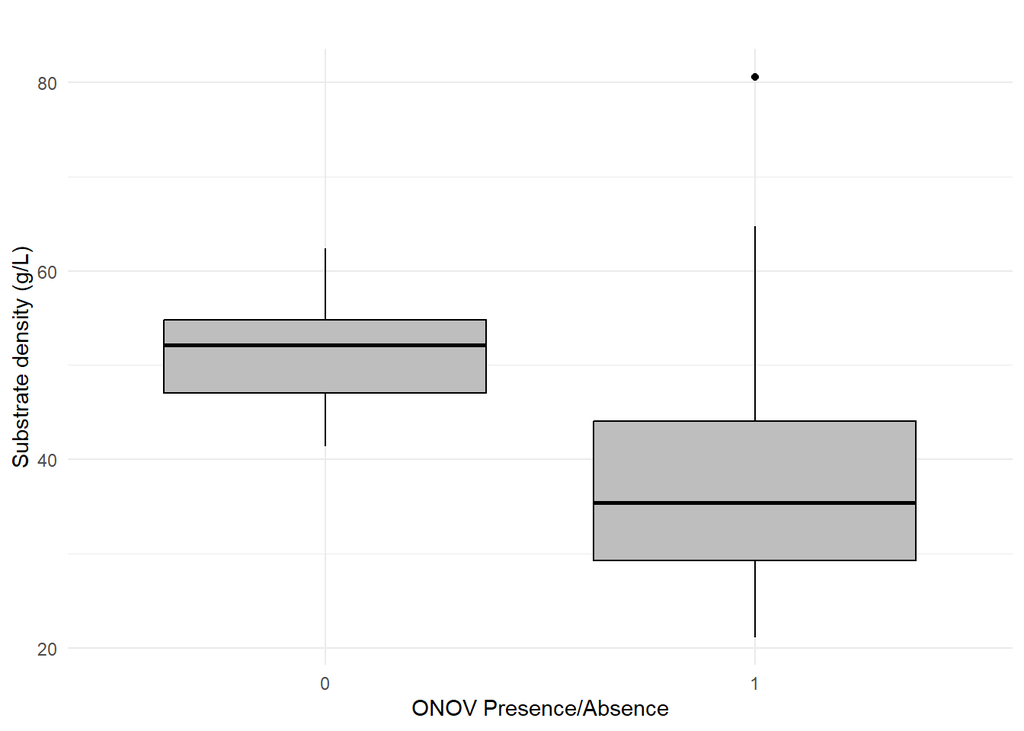

```r
ggplot(mite_combined, aes(x = factor(ONOV), y = SubsDens)) +
  geom_boxplot(fill = "grey", color = "black") +
  labs(x = "ONOV Presence/Absence", y = "Substrate density (g/L)",
       title = " ") +
  theme_minimal() +
  theme(plot.title = element_text(hjust = 0.5, size = 14, face = "bold"))
```

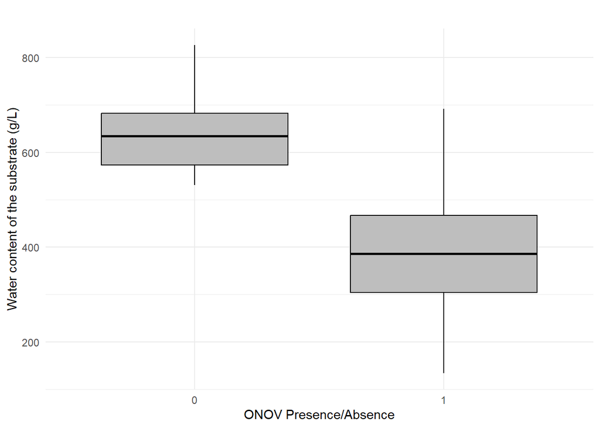

```r
ggplot(mite_combined, aes(x = factor(ONOV), y = WatrCont)) +
  geom_boxplot(fill = "grey", color = "black") +
  labs(x = "ONOV Presence/Absence", y = "Water content of the substrate (g/L)",
       title = " ") +
  theme_minimal() +
  theme(plot.title = element_text(hjust = 0.5, size = 14, face = "bold"))
```

We now repeat the same analysis for the **LCIL** species, examining its presence/absence across the environmental covariates and visualizing its relationship with the numeric variables **SubsDens** and **WatrCont**. We begin by creating contingency tables that show the presence/absence of **LCIL** across the levels of the categorical variables: **Substrate**, **Shrub**, and **Topo**. These tables provide a summary of how the species’ presence is distributed within each level of these environmental factors.

```r
mite_combined %>%
  group_by(Substrate, LCIL) %>%
  summarise(count = n()) %>%
  pivot_wider(names_from = LCIL, values_from = count, values_fill = 0)
```

```
## # A tibble: 7 × 3
## # Groups:   Substrate [7]
##   Substrate   `0`   `1`
##   <fct>     <int> <int>
## 1 Sphagn1       6    19
## 2 Sphagn2       0    11
## 3 Sphagn3       1     0
## 4 Sphagn4       1     1
## 5 Litter        0     2
## 6 Barepeat      0     2
## 7 Interface     7    20
```

```r
# Contingency table for LCIL presence/absence across levels of Shrub
mite_combined %>%
  group_by(Shrub, LCIL) %>%
  summarise(count = n()) %>%
  pivot_wider(names_from = LCIL, values_from = count, values_fill = 0)
```

```
## # A tibble: 3 × 3
## # Groups:   Shrub [3]
##   Shrub   `0`   `1`
##   <ord> <int> <int>
## 1 None      1    18
## 2 Few       3    23
## 3 Many     11    14
```

```r
# Contingency table for LCIL presence/absence across levels of Topo
mite_combined %>%
  group_by(Topo, LCIL) %>%
  summarise(count = n()) %>%
  pivot_wider(names_from = LCIL, values_from = count, values_fill = 0)
```

```
## # A tibble: 2 × 3
## # Groups:   Topo [2]
##   Topo      `0`   `1`
##   <fct>   <int> <int>
## 1 Blanket     4    40
## 2 Hummock    11    15
```

Next, we visualize the distribution of SubsDens (substrate density) based on the presence or absence of LCIL using a boxplot. This helps us understand how substrate density varies with the species’ presence.

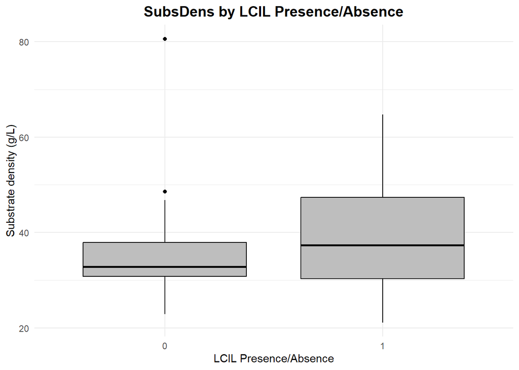

```r
ggplot(mite_combined, aes(x = factor(LCIL), y = SubsDens)) +
  geom_boxplot(fill = "grey", color = "black") +
  labs(x = "LCIL Presence/Absence", y = "Substrate density (g/L)",
       title = "SubsDens by LCIL Presence/Absence") +
  theme_minimal() +
  theme(plot.title = element_text(hjust = 0.5, size = 14, face = "bold"))
```

Finally, we examine the distribution of WatrCont (water content of the substrate) across the presence and absence of LCIL using a boxplot. This provides insight into how water content might influence the species’ occurrence.

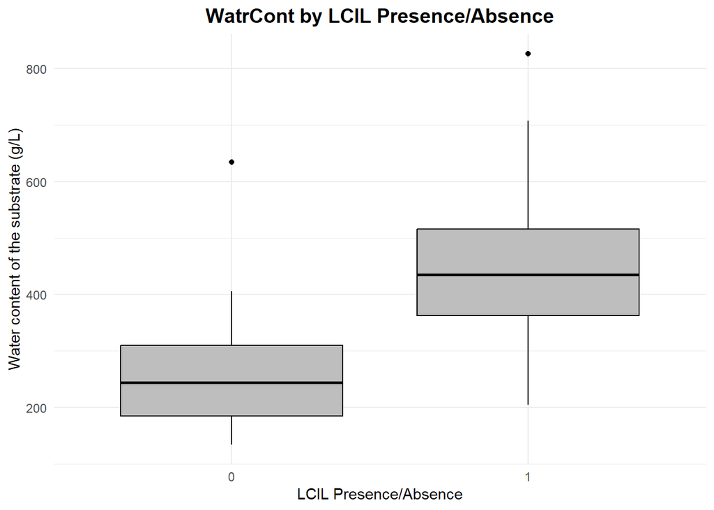

```r
ggplot(mite_combined, aes(x = factor(LCIL), y = WatrCont)) +
  geom_boxplot(fill = "grey", color = "black") +
  labs(x = "LCIL Presence/Absence", y = "Water content of the substrate (g/L)",
       title = "WatrCont by LCIL Presence/Absence") +
  theme_minimal() +
  theme(plot.title = element_text(hjust = 0.5, size = 14, face = "bold"))
```

Now we examine the correlation between the two quantitative variables: **SubsDens** (substrate density) and **WatrCont** (water content). The correlation coefficient is calculated to assess the strength of their relationship.

```r
cor(mite.env$SubsDens, mite.env$WatrCont)
```

```
## [1] 0.3535219
```

The result shows a weak positive correlation between the two variables.

Next, we use the Wilcoxon test to assess whether there are statistically significant differences in the quantitative variables (SubsDens and WatrCont) between the presence and absence of ONOV and LCIL.

```r
wilcox.test(SubsDens ~ ONOV, data = mite_combined)
```

```
##
##  Wilcoxon rank sum test with continuity correction
##
## data:  SubsDens by ONOV
## W = 375, p-value = 0.002571
## alternative hypothesis: true location shift is not equal to 0
```

The Wilcoxon test indicates that the difference in SubsDens between sites with and without ONOV is statistically significant (p-value < 0.05).

```r
wilcox.test(SubsDens ~ LCIL, data = mite_combined)
```

```
##
##  Wilcoxon rank sum test with continuity correction
##
## data:  SubsDens by LCIL
## W = 345, p-value = 0.3376
## alternative hypothesis: true location shift is not equal to 0
```

For LCIL, the difference in SubsDens between the presence and absence of the species is not statistically significant (p-value > 0.05).

```r
wilcox.test(WatrCont ~ ONOV, data = mite_combined)
```

```
##
##  Wilcoxon rank sum test with continuity correction
##
## data:  WatrCont by ONOV
## W = 425, p-value = 6.506e-05
## alternative hypothesis: true location shift is not equal to 0
```

The difference in WatrCont between sites with and without ONOV is statistically significant.

```r
wilcox.test(WatrCont ~ LCIL, data = mite_combined)
```

```
##
##  Wilcoxon rank sum test with continuity correction
##
## data:  WatrCont by LCIL
## W = 113, p-value = 1.872e-05
## alternative hypothesis: true location shift is not equal to 0
```

Similarly, the difference in WatrCont between sites with and without LCIL is also statistically significant. Based on the Wilcoxon test results, we conclude that SubsDens shows a significant difference for ONOV but not for LCIL. On the other hand, WatrCont shows significant differences for both ONOV and LCIL. These results should inform the decision on whether to include SubsDens as a covariate in the autologistic model.

We then conduct Chi-square tests to examine the association between the presence/absence of ONOV and the categorical variables (Substrate, Shrub, and Topo).

```r
chisq.test(table(mite_combined$ONOV, mite_combined$Substrate))
```

```
##
##  Pearson's Chi-squared test
##
## data:  table(mite_combined$ONOV, mite_combined$Substrate)
## X-squared = 18.878, df = 6, p-value = 0.004374
```

```r
chisq.test(table(mite_combined$ONOV, mite_combined$Shrub))
```

```
##
##  Pearson's Chi-squared test
##
## data:  table(mite_combined$ONOV, mite_combined$Shrub)
## X-squared = 13.702, df = 2, p-value = 0.001058
```

```r
chisq.test(table(mite_combined$ONOV, mite_combined$Topo))
```

```
##
##  Pearson's Chi-squared test with Yates' continuity correction
##
## data:  table(mite_combined$ONOV, mite_combined$Topo)
## X-squared = 2.9983, df = 1, p-value = 0.08335
```

We repeat the Chi-square tests for LCIL to assess its relationship with the same categorical variables.

```r
chisq.test(table(mite_combined$LCIL, mite_combined$Substrate))
```

```
##
##  Pearson's Chi-squared test
##
## data:  table(mite_combined$LCIL, mite_combined$Substrate)
## X-squared = 9.1498, df = 6, p-value = 0.1653
```

```r
chisq.test(table(mite_combined$LCIL, mite_combined$Shrub))
```

```
##
##  Pearson's Chi-squared test
##
## data:  table(mite_combined$LCIL, mite_combined$Shrub)
## X-squared = 12.024, df = 2, p-value = 0.002449
```

```r
chisq.test(table(mite_combined$LCIL, mite_combined$Topo))
```

```
##
##  Pearson's Chi-squared test with Yates' continuity correction
##
## data:  table(mite_combined$LCIL, mite_combined$Topo)
## X-squared = 8.8279, df = 1, p-value = 0.002967
```

ONOV shows significant associations with Substrate and Shrub, but not with Topo, while LCIL shows significant associations with Shrub and Topo, but not with Substrate. These results can help inform which categorical variables might be relevant for inclusion in the autologistic model for predicting the presence or absence of ONOV and LCIL.

## Fit the Models

First we assign spatial coordinates to the dataset.

```r
coordinates(mite_combined) <- ~x + y
gridded(mite_combined) <- FALSE
```

Then we define rook and queen spatial neighborhood structures, create adjacency matriceswhich represent the spatial relationships between sites and transform the adjacency matrices into symmetric matrices to ensure consistency in spatial relationships.

```r
rook <- dnearneigh(coordinates(mite_combined), 0, 1)
queen <- dnearneigh(coordinates(mite_combined), 0, 1.5)
rook_spmat <- nb2mat(rook, style = "B", zero.policy = TRUE)
queen_spmat <- nb2mat(queen, style = "B", zero.policy = TRUE)
rook_spmat <- diag(1, 70, 70) %*% rook_spmat
queen_spmat <- diag(1, 70, 70) %*% queen_spmat
```

To compute the neighbor sums we define a function that multiplies the adjacency matrix by the species presence vector and sums the results

```r
calc_neighbors_sum <- function(spmat, species_presence) {
  apply(spmat, 1, function(x) sum(x * species_presence))
}
mite_combined$sum_neighbors_ONOV_rook <- calc_neighbors_sum(rook_spmat, mite_combined$ONOV)
mite_combined$sum_neighbors_LCIL_rook <- calc_neighbors_sum(rook_spmat, mite_combined$LCIL)
mite_combined$sum_neighbors_ONOV_queen <- calc_neighbors_sum(queen_spmat, mite_combined$ONOV)
mite_combined$sum_neighbors_LCIL_queen <- calc_neighbors_sum(queen_spmat, mite_combined$LCIL)
```

Now we are going to fit autologistic models for a given species using the `glm` function. The models incorporate spatial dependencies (neighbor sums) and other covariates.

The function `fit_autologistic_models` accepts the following parameters: - `species`: The binary response variable indicating species presence/absence. - `neighbors_sum`: A variable capturing the sum of neighboring sites’ species presence. - `data`: The dataset containing the covariates and response variable.

Based on the exploratory analysis, the quantitative variable “WatrCont” is significant for both species, ONOV and LCIL. Therefore, we fit a simplified model using only “WatrCont” and the neighbor sum as predictors. For comparison, we also fit a full model that includes all covariates, including potentially non-significant ones.

```r
fit_autologistic_models <- function(species, neighbors_sum, data) {
  list(
    with_WatrCont = glm(species ~ WatrCont + neighbors_sum, family = binomial, data = data),
    full = glm(species ~ SubsDens + WatrCont + Shrub + Topo + Substrate + neighbors_sum, family = binomial, data = data)
  )
}
```

We estimate autologistic models for the species ONOV and LCIL using two spatial neighborhood structures: **Rook** and **Queen**. For each structure: - Two models are fitted using the `fit_autologistic_models` function: 1. **With Water Content (`with_WatrCont`)**: Includes water content (`WatrCont`) and the spatial neighbor sum (`neighbors_sum`) as predictors. 2. **Full Model (`full`)**: Includes all covariates (`SubsDens`, `WatrCont`, `Shrub`, `Topo`, `Substrate`) and neighbor sum.

The Akaike Information Criterion (AIC) is calculated for each model to compare their goodness of fit while penalizing for complexity. Based on the AIC values, the best model for each combination of species and spatial structure is chosen. The model with “WatrCont” is selected.

```
##                   Model       AIC
## 1  ONOV Rook - WatrCont  25.87046
## 2      ONOV Rook - Full 242.26192
## 3  LCIL Rook - WatrCont  53.73964
## 4      LCIL Rook - Full  60.42533
## 5 ONOV Queen - WatrCont  27.33621
## 6     ONOV Queen - Full 242.26192
## 7 LCIL Queen - WatrCont  51.83354
## 8     LCIL Queen - Full  59.21647
```

### Prediction accuracy

We define a function, `predict_accuracy`, to evaluate the performance of the selected models: 1. **Predicted Probabilities**: Calculated using the `predict` function with `type = "response"`. 2. **Predicted Classes**: Converted to binary predictions based on a threshold of 0.5. 3. **Confusion Matrix**: A table comparing observed and predicted classes. 4. **Accuracy**: Computed as the percentage of correctly classified instances.

```r
predict_accuracy <- function(model, species_presence, data) {
  predicted_prob <- predict(model, type = "response")
  predicted_class <- ifelse(predicted_prob > 0.5, 1, 0)
  table_result <- table(species_presence, predicted_class)
  accuracy <- 100 * sum(diag(table_result)) / sum(table_result)
  list(table = table_result, accuracy = accuracy)
}
```

We then compare the accuracy of the autologistic models built using the “glm” function with the ones built using the function “autologistic” from package “ngspatial”.

```r
fit_ngspatial <- function(species_presence, data, spmat) {
  autologistic(species_presence ~ coordinates(data) + data$WatrCont - 1,
               data, spmat, method = "PL", control = list(nodes = 2, confint = "bootstrap", bootit = 200))
}
```

```
##                            model accuracy
## 1  ngspatial ngspatial_ONOV_rook 82.85714
## 2  ngspatial ngspatial_LCIL_rook 84.28571
## 3 ngspatial ngspatial_ONOV_queen 87.14286
## 4 ngspatial ngspatial_LCIL_queen 87.14286
## 5              glm glm_ONOV_rook 90.00000
## 6              glm glm_LCIL_rook 88.57143
## 7             glm glm_ONOV_queen 94.28571
## 8             glm glm_LCIL_queen 87.14286
```

The autologistic models built using the function “glm” seem more accurate.

#### Fit Simple Logistic Models

For comparison, simple logistic regression models are fitted for each species using `WatrCont` as the predictor and the predictive maps for autologistic and simple logistic models are visualized:

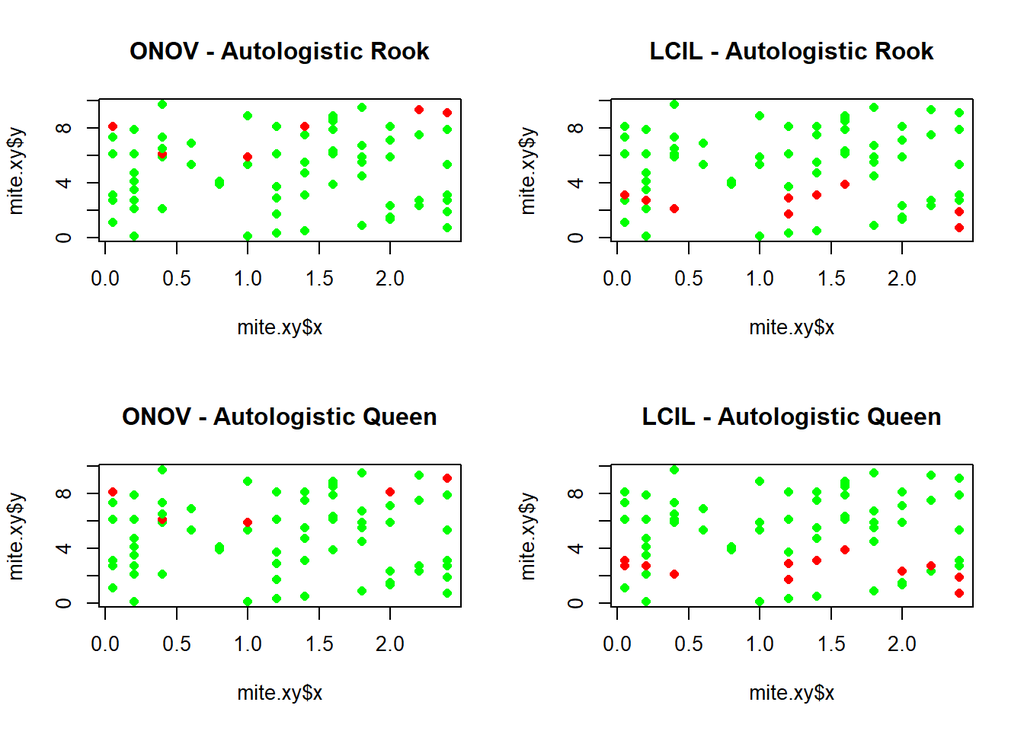

```r
par(mfrow = c(2, 2)) # 2x2 grid for the maps

# ONOV - Rook
plot(mite.xy$x, mite.xy$y, col = ifelse(pred_autologistic_ONOV_rook == 1, "green", "red"), pch = 16, main = "ONOV - Autologistic Rook")
# LCIL - Rook
plot(mite.xy$x, mite.xy$y, col = ifelse(pred_autologistic_LCIL_rook == 1, "green", "red"), pch = 16, main = "LCIL - Autologistic Rook")
# ONOV - Queen
plot(mite.xy$x, mite.xy$y, col = ifelse(pred_autologistic_ONOV_queen == 1, "green", "red"), pch = 16, main = "ONOV - Autologistic Queen")
# LCIL - Queen
plot(mite.xy$x, mite.xy$y, col = ifelse(pred_autologistic_LCIL_queen == 1, "green", "red"), pch = 16, main = "LCIL - Autologistic Queen")
```

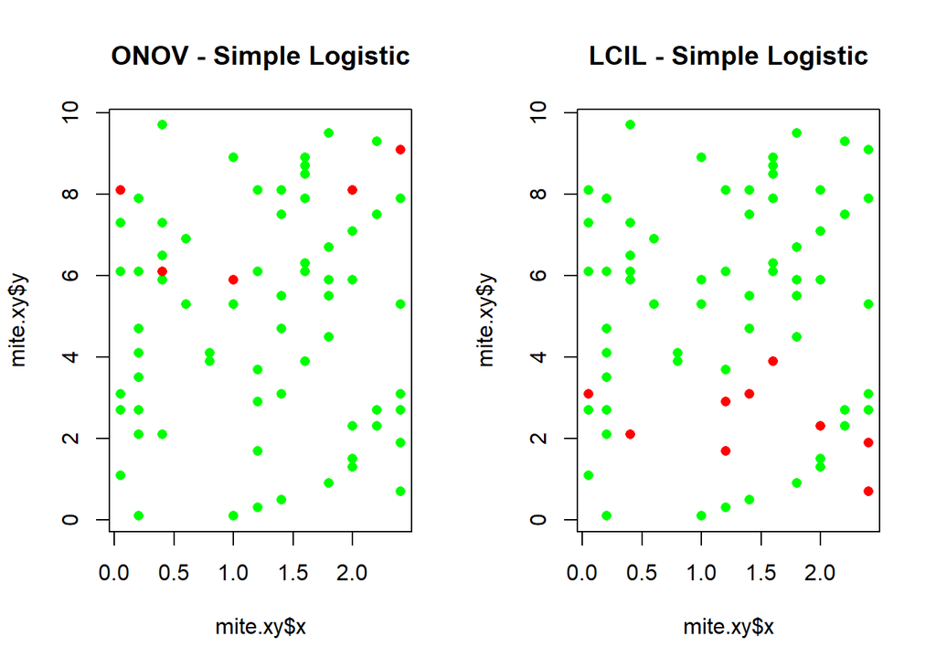

```r
par(mfrow = c(1, 2)) # 1x2 grid for the maps

# ONOV - Simple Logistic
plot(mite.xy$x, mite.xy$y, col = ifelse(pred_simple_logistic_ONOV == 1, "green", "red"), pch = 16, main = "ONOV - Simple Logistic")
# LCIL - Simple Logistic
plot(mite.xy$x, mite.xy$y, col = ifelse(pred_simple_logistic_LCIL == 1, "green", "red"), pch = 16, main = "LCIL - Simple Logistic")
```

The accuracy of the simple logistic models is calculated using the predict_accuracy function previously defined:

```
##                  Model Accuracy
## 1 Simple_Logistic_ONOV    94.29
## 2 Simple_Logistic_LCIL    88.57
```

The simple logistic models perform very well and similar to the spatial autologistic models in terms of accuracy of the predictions.